# STSCI 4630 - Lec 09

Harry Lu

Feburary 19, 2019

**Reducing Risk for Portfolios of $N$ Risky Assets**

Assets $A_1,\cdots,A_N$

Returns $R_1,\cdots,R_N$

$\text{E}(R_i)=\mu_i$, $\text{Var}(R_i)=\sigma_i^2$, $\text{Cov}(R_i,R_j)=\rho_{ij}\sigma_i\sigma_j$, $\rho_{ij}=\text{Corr}(R_i,R_j)$

$$\mathbf{R}=\left(\begin{array}{c}R_1\\\vdots\\R_N\end{array}\right)$$

$$\boldsymbol{\mu}=\text{E}(\mathbf{R})=\left(\begin{array}{c}\mu_1\\\vdots\\\mu_N\end{array}\right)$$

$$\Omega=\text{Cov}(\mathbf{R})=\left(\begin{array}{c}
\text{Var}(R_1)&\text{Cov}(R_1,R_2)&\cdots&\text{Cov}(R_1,R_N)\\
\text{Cov}(R_2,R_1)&\text{Var}(R_2)&\cdots&\text{Cov}(R_2,R_N)\\
\vdots&\vdots&\ddots&\vdots\\
\text{Cov}(R_N,R_1)&\text{Cov}(R_N,R_2)&\cdots&\text{Var}(R_N)
\end{array}\right)$$

Portfolio $P$ puts weights $w_1,\cdots,w_N$ on $A_1,\cdots,A_N$, where $\sum_{i=1}^{N}w_i=1$

Portfolio returns $R_p=w_1\cdot R_1+\cdots+w_N\cdot R_N=\mathbf{w}^T\cdot\mathbf{R}$ where $\mathbf{w}=\left(\begin{array}{c}{w_1\\\vdots\\w_N}\end{array}\right)$

$\text{E}(R_p)=\mu_p=w_1\cdot\mu_1+\cdots+w_N\cdot\mu_N=\mathbf{w}^T\cdot\boldsymbol{\mu}$

$\text{Var}(R_p)=\sigma_p^2=\mathbf{w}^T\Omega\mathbf{w}$

Goal: For given $\mu_p$, find weights $w_1,\cdots,w_N$ that minimize $\mathbf{w}^T\Omega\mathbf{w}$ subject to the constraints $\mathbf{w}^T\boldsymbol{\mu}=\mu_p$ and $\mathbf{w}^T\cdot\mathbf{J}=1$ where $\mathbf{J}=\left(\begin{array}{c}{1\\\vdots\\1}\end{array}\right)$

**Quadratic Programming**

Given:

- $N\times N$ matrix $D$
- $N\times1$ vector $\mathbf{d}$
- $N\times(m_{\text{eq}}+m_{\text{neq}})$ matrix $A=\left(\begin{array}{c}A_{\text{eq}}&A_{\text{neq}}\end{array}\right)$ where $A_{\text{eq}}$ is the $m_{\text{eq}}$ columns and $A_{\text{neq}}$ is the $m_{\text{neq}}$ columns
- $(m_{\text{eq}}+m_{\text{neq}})\times1$ vector $\mathbf{b}=\left(\begin{array}{c}\mathbf{b}_{\text{eq}}\\\mathbf{b}_{\text{neq}}\end{array}\right)$ where $\mathbf{b}_{\text{eq}}$ is the $m_{\text{eq}}$ rows and $\mathbf{b}_{\text{neq}}$ is the $m_{\text{neq}}$ rows

Find the $N\times1$ vector $\mathbf{x}$ that minimizes $\frac{1}{2}\mathbf{x}^TD\mathbf{x}-\mathbf{d}^T\mathbf{x}$ subject to the constraints $A_{\text{eq}}^T\mathbf{x}=\mathbf{b}_{\text{eq}}$ and $A_{\text{neq}}^T\mathbf{x}\geq\mathbf{b}_{\text{neq}}$

Our goal:

- $\mathbf{x}=\mathbf{w}$
- $D=2\Omega$
- $\mathbf{d}=\left(\begin{array}{c}{0\\\vdots\\0}\end{array}\right)=\mathbf{0}_{n\times1}$
- $A=A_{\text{eq}}=\left(\begin{array}{c}1&\mu_1\\\vdots&\vdots\\1&\mu_N\end{array}\right)$
- $\mathbf{b}=\left(\begin{array}{c}1\\\mu_p\end{array}\right)$

Suppose we want the weights to be all non-negative, add the condition $w_1\geq0,\cdots,w_N\geq0$ use $m_{\text{eq}}=2$, $m_{\text{neq}}=N$

$A=\left(\left.\begin{array}{c}1&\mu_1\\\vdots&\vdots\\1&\mu_N\end{array}\right|I_N\right)$, $A_{\text{eq}}$ as before, $A_{\text{neq}}=I_{N\times N}$

$\mathbf{b}_{(N+2)\times1}=\left(\begin{array}{c}{1\\\mu_p\\0\\\vdots\\0}\end{array}\right)$, $\mathbf{b}_{\text{eq}}$ as before, $\mathbf{b}_{\text{neq}}=\mathbf{0}_{N\times1}$

Suppose we want the weights to be in ranges: $-a_1\leq w_1\leq b_1,\cdots,-a_N\leq w_N\leq b_N$

$A=\left(\left.\left.\begin{array}{c}1&\mu_1\\\vdots&\vdots\\1&\mu_N\end{array}\right|I_N\right|-I_N\right)$

$w_1\leq b_1,\cdots,w_N\leq b_N \leftrightarrow -w_1\geq-b_1,\cdots,-w_N\geq-b_N$

**Combining two or more risky assets with a risk-free asset**

“Efficient Frontier” & “Tangency Portfolio” Sharpe Ratio

**Recall risky-asset and one risk-free asset**

$R_p=w\cdot R_1+(1-w)\cdot\mu_f=\mu_f+w\cdot(R_1-\mu_f)$

$\mu_p=\mu_f+w\cdot(\mu_1-\mu_f)$

$\sigma_p=|w|\cdot\sigma_1$

For given $\mu_p$: $w=\frac{\mu_p-\mu_f}{\mu_1-\mu_f}$

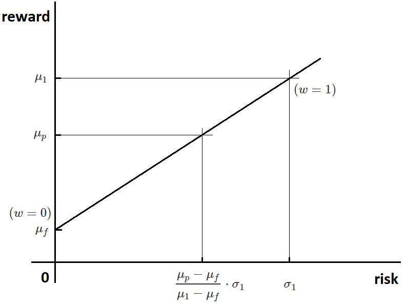

**Recall two risky assets**

$R_p=w\cdot R_1+(1-w)\cdot R_2=R_2+w\cdot(R_1-R_2)$

$\mu_p=\mu_2+w\cdot(\mu_1-\mu_2)$

$\sigma_p^2=w^2\sigma_1^2+(1-w)^2\sigma_2^2+2w(1-w)\rho_{12}\sigma_1\sigma_2$

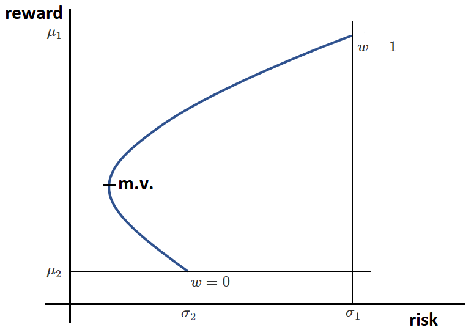

**Now we want to mix two risky assets with the risk-free asset**

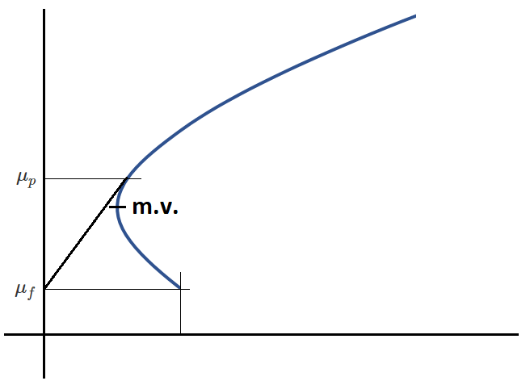

Combine the two risky assets into a single risky asset by looking at portfolios on the efficient frontier. Suppose a portfolio on the efficient frontier has return $R_p$ with reward $\mu_p=\text{E}(R_p)$

Consider a portfolio $L$ that mixes the efficient frontier portfolio with the risk-free asset

Thanks to *Zhenjie Shen* for help with the notes.